# Определение перспективного тарифа для телеком компании

## Описание исследования

Клиентам предлагают два тарифных плана: «Смарт» и «Ультра». Чтобы скорректировать рекламный бюджет, коммерческий департамент хочет понять, какой тариф приносит больше денег.  
В нашем распоряжении данные 500 пользователей «Мегалайна»: кто они, откуда, каким тарифом пользуются, сколько звонков и сообщений каждый отправил за 2018 год. Нужно проанализировать поведение клиентов и сделать вывод — какой тариф лучше.

## Содержание

1. Изучение общей информации
2. Предобработка данных
   1. Обработаем таблицу с сообщениями
   2. Обработаем таблицу со звонками
   3. Обработаем таблицу с трафиком
   4. Обработаем таблицу с пользователем
   5. Найдем необходимые параметры
3. Анализ
4. Проверка гипотез
5. Общий вывод

## Шаг 0. Импорт всех необходимых библиотек

```python
import pandas as pd
import numpy as np
from scipy import stats as st
import math
```

## Шаг 1. Изучение общей информации

```python
calls = pd.read_csv('/datasets/calls.csv')
internet = pd.read_csv('/datasets/internet.csv')
messages = pd.read_csv('/datasets/messages.csv')
tariffs = pd.read_csv('/datasets/tariffs.csv')
users = pd.read_csv('/datasets/users.csv')
```

```python
calls.info()
print()
internet.info()
print()
messages.info()
print()
tariffs.info()
print()
users.info()
```

```
<class 'pandas.core.frame.DataFrame'>
RangeIndex: 202607 entries, 0 to 202606
Data columns (total 4 columns):
 #   Column     Non-Null Count   Dtype
---  ------     --------------   -----
 0   id         202607 non-null  object
 1   call_date  202607 non-null  object
 2   duration   202607 non-null  float64
 3   user_id    202607 non-null  int64
dtypes: float64(1), int64(1), object(2)
memory usage: 6.2+ MB

<class 'pandas.core.frame.DataFrame'>
RangeIndex: 149396 entries, 0 to 149395
Data columns (total 5 columns):
 #   Column        Non-Null Count   Dtype
---  ------        --------------   -----
 0   Unnamed: 0    149396 non-null  int64
 1   id            149396 non-null  object
 2   mb_used       149396 non-null  float64
 3   session_date  149396 non-null  object
 4   user_id       149396 non-null  int64
dtypes: float64(1), int64(2), object(2)
memory usage: 5.7+ MB

<class 'pandas.core.frame.DataFrame'>
RangeIndex: 123036 entries, 0 to 123035
Data columns (total 3 columns):
 #   Column        Non-Null Count   Dtype
---  ------        --------------   -----
 0   id            123036 non-null  object
 1   message_date  123036 non-null  object
 2   user_id       123036 non-null  int64
dtypes: int64(1), object(2)
memory usage: 2.8+ MB

<class 'pandas.core.frame.DataFrame'>
RangeIndex: 2 entries, 0 to 1
Data columns (total 8 columns):
 #   Column                 Non-Null Count  Dtype
```

[output cut: 12 more lines]

```
<class 'pandas.core.frame.DataFrame'>
RangeIndex: 500 entries, 0 to 499
Data columns (total 8 columns):
 #   Column      Non-Null Count  Dtype
---  ------      --------------  -----
 0   user_id     500 non-null    int64
 1   age         500 non-null    int64
 2   churn_date  38 non-null     object
 3   city        500 non-null    object
 4   first_name  500 non-null    object
 5   last_name   500 non-null    object
 6   reg_date    500 non-null    object
 7   tariff      500 non-null    object
dtypes: int64(2), object(6)
memory usage: 31.4+ KB
```

## Шаг 2. Предобработка данных

### Обработаем таблицу с сообщениями

```python
messages.head()
```

|  | id | message_date | user_id |
| --- | --- | --- | --- |
| 0 | 1000_0 | 2018-06-27 | 1000 |
| 1 | 1000_1 | 2018-10-08 | 1000 |
| 2 | 1000_2 | 2018-08-04 | 1000 |
| 3 | 1000_3 | 2018-06-16 | 1000 |
| 4 | 1000_4 | 2018-12-05 | 1000 |

```python
messages['message_date'] = pd.to_datetime(messages['message_date'],format='%Y-%m-%d')
messages['message_date'].head()
```

```
0   2018-06-27
1   2018-10-08
2   2018-08-04
3   2018-06-16
4   2018-12-05
Name: message_date, dtype: datetime64[ns]
```

```python
messages['id'] = messages['id'].apply(lambda x: int(x.split('_')[1]))
messages.tail()
```

|  | id | message_date | user_id |
| --- | --- | --- | --- |
| 123031 | 179 | 2018-12-12 | 1499 |
| 123032 | 180 | 2018-09-28 | 1499 |
| 123033 | 181 | 2018-09-27 | 1499 |
| 123034 | 182 | 2018-11-15 | 1499 |
| 123035 | 183 | 2018-11-16 | 1499 |

```python
messages.isna().sum()
```

```
id              0
message_date    0
user_id         0
dtype: int64
```

```python
messages.duplicated().sum()
```

```
0
```

### Обработаем таблицу со звонками

```python
calls.head()
```

|  | id | call_date | duration | user_id |
| --- | --- | --- | --- | --- |
| 0 | 1000_0 | 2018-07-25 | 0.00 | 1000 |
| 1 | 1000_1 | 2018-08-17 | 0.00 | 1000 |
| 2 | 1000_2 | 2018-06-11 | 2.85 | 1000 |
| 3 | 1000_3 | 2018-09-21 | 13.80 | 1000 |
| 4 | 1000_4 | 2018-12-15 | 5.18 | 1000 |

```python
# удалим те строчки,в которых длина звонка равна нулю
calls = calls.query('duration > 0').reset_index(drop=True)
calls.head()
```

|  | id | call_date | duration | user_id |
| --- | --- | --- | --- | --- |
| 0 | 1000_2 | 2018-06-11 | 2.85 | 1000 |
| 1 | 1000_3 | 2018-09-21 | 13.80 | 1000 |
| 2 | 1000_4 | 2018-12-15 | 5.18 | 1000 |
| 3 | 1000_7 | 2018-08-22 | 18.31 | 1000 |
| 4 | 1000_8 | 2018-09-15 | 18.44 | 1000 |

```python
#оставим только id,отрезав id пользователя
calls['id'] = calls['id'].apply(lambda x: int(x.split('_')[1]))
calls.head()
```

|  | id | call_date | duration | user_id |
| --- | --- | --- | --- | --- |
| 0 | 2 | 2018-06-11 | 2.85 | 1000 |
| 1 | 3 | 2018-09-21 | 13.80 | 1000 |
| 2 | 4 | 2018-12-15 | 5.18 | 1000 |
| 3 | 7 | 2018-08-22 | 18.31 | 1000 |
| 4 | 8 | 2018-09-15 | 18.44 | 1000 |

```python
# переведем дату из строки в pd datetime
calls['call_date'] = pd.to_datetime(calls['call_date'],format='%Y-%m-%d')
calls['call_date'].head()
```

```
0   2018-06-11
1   2018-09-21
2   2018-12-15
3   2018-08-22
4   2018-09-15
Name: call_date, dtype: datetime64[ns]
```

```python
#функция перевода минут в секунды
def setting_duration(duration):
    return math.ceil(duration)

calls['duration'] = calls['duration'].apply(setting_duration)
calls['duration'].head()
```

```
0     3
1    14
2     6
3    19
4    19
Name: duration, dtype: int64
```

```python
calls.isna().sum()
```

```
id           0
call_date    0
duration     0
user_id      0
dtype: int64
```

```python
calls.duplicated().sum()
```

```
0
```

### Обработаем таблицу с трафиком

```python
internet.head()
```

|  | Unnamed: 0 | id | mb_used | session_date | user_id |
| --- | --- | --- | --- | --- | --- |
| 0 | 0 | 1000_0 | 112.95 | 2018-11-25 | 1000 |
| 1 | 1 | 1000_1 | 1052.81 | 2018-09-07 | 1000 |
| 2 | 2 | 1000_2 | 1197.26 | 2018-06-25 | 1000 |
| 3 | 3 | 1000_3 | 550.27 | 2018-08-22 | 1000 |
| 4 | 4 | 1000_4 | 302.56 | 2018-09-24 | 1000 |

```python
# удалим неизвестную колонку
internet.drop('Unnamed: 0',axis='columns',inplace=True)
internet.head()
```

|  | id | mb_used | session_date | user_id |
| --- | --- | --- | --- | --- |
| 0 | 1000_0 | 112.95 | 2018-11-25 | 1000 |
| 1 | 1000_1 | 1052.81 | 2018-09-07 | 1000 |
| 2 | 1000_2 | 1197.26 | 2018-06-25 | 1000 |
| 3 | 1000_3 | 550.27 | 2018-08-22 | 1000 |
| 4 | 1000_4 | 302.56 | 2018-09-24 | 1000 |

```python
#оставим только id,отрезав id пользователя
internet['id'] = internet['id'].apply(lambda x: int(x.split('_')[1]))
internet.head()
```

|  | id | mb_used | session_date | user_id |
| --- | --- | --- | --- | --- |
| 0 | 0 | 112.95 | 2018-11-25 | 1000 |
| 1 | 1 | 1052.81 | 2018-09-07 | 1000 |
| 2 | 2 | 1197.26 | 2018-06-25 | 1000 |
| 3 | 3 | 550.27 | 2018-08-22 | 1000 |
| 4 | 4 | 302.56 | 2018-09-24 | 1000 |

```python
# переведем дату из строки в pd datetime
internet['session_date'] = pd.to_datetime(internet['session_date'],format='%Y-%m-%d')
internet['session_date'].head()
```

```
0   2018-11-25
1   2018-09-07
2   2018-06-25
3   2018-08-22
4   2018-09-24
Name: session_date, dtype: datetime64[ns]
```

```python
# округлим значение израсходованного трафика в большую сторону
internet['mb_used'] = internet['mb_used'].apply(lambda x: math.ceil(x))
```

```python
internet.isna().sum()
```

```
id              0
mb_used         0
session_date    0
user_id         0
dtype: int64
```

```python
internet.duplicated().sum()
```

```
0
```

### Обработка таблицы пользователей

```python
users.head()
```

|  | user_id | age | churn_date | city | first_name | last_name | reg_date | tariff |
| --- | --- | --- | --- | --- | --- | --- | --- | --- |
| 0 | 1000 | 52 | NaN | Краснодар | Рафаил | Верещагин | 2018-05-25 | ultra |
| 1 | 1001 | 41 | NaN | Москва | Иван | Ежов | 2018-11-01 | smart |
| 2 | 1002 | 59 | NaN | Стерлитамак | Евгений | Абрамович | 2018-06-17 | smart |
| 3 | 1003 | 23 | NaN | Москва | Белла | Белякова | 2018-08-17 | ultra |
| 4 | 1004 | 68 | NaN | Новокузнецк | Татьяна | Авдеенко | 2018-05-14 | ultra |

```python
users.isna().sum()
```

```
user_id         0
age             0
churn_date    462
city            0
first_name      0
last_name       0
reg_date        0
tariff          0
dtype: int64
```

```python
users['churn_date'].fillna(0,inplace=True)
```

```python
users['reg_date'] = pd.to_datetime(users['reg_date'],format='%Y-%m-%d')
users['reg_date'].head()
```

```
0   2018-05-25
1   2018-11-01
2   2018-06-17
3   2018-08-17
4   2018-05-14
Name: reg_date, dtype: datetime64[ns]
```

```python
users['tariff'].unique()
```

```
array(['ultra', 'smart'], dtype=object)
```

```python
def into_lower(row):
    row['city'], row['first_name'], row['last_name'] = row['city'].lower(), row['first_name'].lower(), row['last_name'].lower()
    return row
```

```python
users = users.apply(into_lower,axis=1)
users.head()
```

|  | user_id | age | churn_date | city | first_name | last_name | reg_date | tariff |
| --- | --- | --- | --- | --- | --- | --- | --- | --- |
| 0 | 1000 | 52 | 0 | краснодар | рафаил | верещагин | 2018-05-25 | ultra |
| 1 | 1001 | 41 | 0 | москва | иван | ежов | 2018-11-01 | smart |
| 2 | 1002 | 59 | 0 | стерлитамак | евгений | абрамович | 2018-06-17 | smart |
| 3 | 1003 | 23 | 0 | москва | белла | белякова | 2018-08-17 | ultra |
| 4 | 1004 | 68 | 0 | новокузнецк | татьяна | авдеенко | 2018-05-14 | ultra |

```python
users.duplicated().sum()
```

```
0
```

```python
tariffs
```

|  | messages_included | mb_per_month_included | minutes_included | rub_monthly_fee | rub_per_gb | rub_per_message | rub_per_minute | tariff_name |
| --- | --- | --- | --- | --- | --- | --- | --- | --- |
| 0 | 50 | 15360 | 500 | 550 | 200 | 3 | 3 | smart |
| 1 | 1000 | 30720 | 3000 | 1950 | 150 | 1 | 1 | ultra |

```python
# добавим в таблицу пользователей информацию об их тарифе
def setting_tariff_info(row):
    tariff_name = row['tariff']
    tariff_info = tariffs[tariffs['tariff_name'] == tariff_name]

    row['messages_included'],row['mb_per_month_included'], row['minutes_included'], row['rub_monthly_fee'], row['rub_per_gb'], row['rub_per_message'], row['rub_per_minute'] = tariff_info['messages_included'].values[0], tariff_info['mb_per_month_included'].values[0], tariff_info['minutes_included'].values[0], tariff_info['rub_monthly_fee'].values[0], tariff_info['rub_per_gb'].values[0], tariff_info['rub_per_message'].values[0], tariff_info['rub_per_minute'].values[0]
    return row
```

```python
users = users.apply(setting_tariff_info,axis=1)
users.head()
```

|  | user_id | age | churn_date | city | first_name | last_name | reg_date | tariff | messages_included | mb_per_month_included | minutes_included | rub_monthly_fee | rub_per_gb | rub_per_message | rub_per_minute |
| --- | --- | --- | --- | --- | --- | --- | --- | --- | --- | --- | --- | --- | --- | --- | --- |
| 0 | 1000 | 52 | 0 | краснодар | рафаил | верещагин | 2018-05-25 | ultra | 1000 | 30720 | 3000 | 1950 | 150 | 1 | 1 |
| 1 | 1001 | 41 | 0 | москва | иван | ежов | 2018-11-01 | smart | 50 | 15360 | 500 | 550 | 200 | 3 | 3 |
| 2 | 1002 | 59 | 0 | стерлитамак | евгений | абрамович | 2018-06-17 | smart | 50 | 15360 | 500 | 550 | 200 | 3 | 3 |
| 3 | 1003 | 23 | 0 | москва | белла | белякова | 2018-08-17 | ultra | 1000 | 30720 | 3000 | 1950 | 150 | 1 | 1 |
| 4 | 1004 | 68 | 0 | новокузнецк | татьяна | авдеенко | 2018-05-14 | ultra | 1000 | 30720 | 3000 | 1950 | 150 | 1 | 1 |

```python
users.duplicated().sum()
```

```
0
```

### Найдем необходимые параметры

#### Посчитаем то,сколько каждый пользователь тратил в месяц минут на разговоры

```python
calls.head()
```

|  | id | call_date | duration | user_id |
| --- | --- | --- | --- | --- |
| 0 | 2 | 2018-06-11 | 3 | 1000 |
| 1 | 3 | 2018-09-21 | 14 | 1000 |
| 2 | 4 | 2018-12-15 | 6 | 1000 |
| 3 | 7 | 2018-08-22 | 19 | 1000 |
| 4 | 8 | 2018-09-15 | 19 | 1000 |

```python
calls['month'] = calls['call_date'].apply(lambda x: x.month)
calls.head(1)
```

|  | id | call_date | duration | user_id | month |
| --- | --- | --- | --- | --- | --- |
| 0 | 2 | 2018-06-11 | 3 | 1000 | 6 |

```python
calls_per_month = calls.pivot_table(index=['user_id','month'],values='duration',aggfunc=['count','sum']).set_axis(['calls_amount','total_duration'],axis='columns')
calls_per_month.head(10)
```

| user_id | month | calls_amount | total_duration |
| --- | --- | --- | --- |
| 1000 | 5 | 17 | 159 |
|  | 6 | 28 | 172 |
|  | 7 | 41 | 340 |
|  | 8 | 42 | 408 |
|  | 9 | 46 | 466 |
|  | 10 | 44 | 350 |
|  | 11 | 37 | 338 |
|  | 12 | 38 | 333 |
| 1001 | 11 | 45 | 430 |
|  | 12 | 47 | 414 |

#### Посчитаем то,сколько каждый пользователь отправлял смс в месяц

```python
messages.head()
```

|  | id | message_date | user_id |
| --- | --- | --- | --- |
| 0 | 0 | 2018-06-27 | 1000 |
| 1 | 1 | 2018-10-08 | 1000 |
| 2 | 2 | 2018-08-04 | 1000 |
| 3 | 3 | 2018-06-16 | 1000 |
| 4 | 4 | 2018-12-05 | 1000 |

```python
messages['month'] = messages['message_date'].apply(lambda x: x.month)
messages.head(1)
```

|  | id | message_date | user_id | month |
| --- | --- | --- | --- | --- |
| 0 | 0 | 2018-06-27 | 1000 | 6 |

```python
messages_per_month = messages.pivot_table(index=['user_id','month'],values='message_date',aggfunc='count').set_axis(['messages_amount'],axis='columns')
messages_per_month.head(10)
```

| user_id | month | messages_amount |
| --- | --- | --- |
| 1000 | 5 | 22 |
|  | 6 | 60 |
|  | 7 | 75 |
|  | 8 | 81 |
|  | 9 | 57 |
|  | 10 | 73 |
|  | 11 | 58 |
|  | 12 | 70 |
| 1002 | 6 | 4 |
|  | 7 | 11 |

#### Посчитаем то,сколько каждый пользователь использовал трафика каждый месяц

```python
internet.head()
```

|  | id | mb_used | session_date | user_id |
| --- | --- | --- | --- | --- |
| 0 | 0 | 113 | 2018-11-25 | 1000 |
| 1 | 1 | 1053 | 2018-09-07 | 1000 |
| 2 | 2 | 1198 | 2018-06-25 | 1000 |
| 3 | 3 | 551 | 2018-08-22 | 1000 |
| 4 | 4 | 303 | 2018-09-24 | 1000 |

```python
internet['month'] = internet['session_date'].apply(lambda x: x.month)
internet.head(1)
```

|  | id | mb_used | session_date | user_id | month |
| --- | --- | --- | --- | --- | --- |
| 0 | 0 | 113 | 2018-11-25 | 1000 | 11 |

```python
internet_per_month = internet.pivot_table(index=['user_id','month'],values='mb_used',aggfunc='sum')
internet_per_month.head(10)
```

| user_id | month | mb_used |
| --- | --- | --- |
| 1000 | 5 | 2256 |
|  | 6 | 23257 |
|  | 7 | 14016 |
|  | 8 | 14070 |
|  | 9 | 14581 |
|  | 10 | 14717 |
|  | 11 | 14768 |
|  | 12 | 9827 |
| 1001 | 11 | 18452 |
|  | 12 | 14053 |

#### Соберем полученные данные в один датасет

```python
used_data = internet_per_month.join(messages_per_month,how='outer').join(calls_per_month,how='outer')
used_data.head(10)
```

| user_id | month | mb_used | messages_amount | calls_amount | total_duration |
| --- | --- | --- | --- | --- | --- |
| 1000 | 5 | 2256.0 | 22.0 | 17.0 | 159.0 |
|  | 6 | 23257.0 | 60.0 | 28.0 | 172.0 |
|  | 7 | 14016.0 | 75.0 | 41.0 | 340.0 |
|  | 8 | 14070.0 | 81.0 | 42.0 | 408.0 |
|  | 9 | 14581.0 | 57.0 | 46.0 | 466.0 |
|  | 10 | 14717.0 | 73.0 | 44.0 | 350.0 |
|  | 11 | 14768.0 | 58.0 | 37.0 | 338.0 |
|  | 12 | 9827.0 | 70.0 | 38.0 | 333.0 |
| 1001 | 11 | 18452.0 | NaN | 45.0 | 430.0 |
|  | 12 | 14053.0 | NaN | 47.0 | 414.0 |

```python
calls_per_month['total_duration'].sum(), used_data['total_duration'].sum()
```

```
(1450301, 1450301.0)
```

```python
used_data.isna().sum()
```

```
mb_used             11
messages_amount    497
calls_amount        46
total_duration      46
dtype: int64
```

Мы видим,что в нашей конечной сводной таблице встречаются значения типа NaN,можно предположить,что если значение NaN,то пользователь не отправлял сообщений или не делал звонков.Поэтому самым логичным действием будет заменить их на ноль.

```python
used_data.fillna(0,inplace=True)
```

```python
used_data.isna().sum()
```

```
mb_used            0
messages_amount    0
calls_amount       0
total_duration     0
dtype: int64
```

#### Теперь можно посчитать выручку по каждому пользователю в месяц

```python
#добавим каждому пользователю его тариф,город и информацию по тарифу
used_data = used_data.join(users[['user_id','tariff','city','messages_included','mb_per_month_included','minutes_included','rub_monthly_fee','rub_per_gb','rub_per_message','rub_per_minute']].set_index('user_id'),on='user_id')
used_data.head()
```

| user_id | month | mb_used | messages_amount | calls_amount | total_duration | tariff | city | messages_included | mb_per_month_included | minutes_included | rub_monthly_fee | rub_per_gb | rub_per_message | rub_per_minute |
| --- | --- | --- | --- | --- | --- | --- | --- | --- | --- | --- | --- | --- | --- | --- |
| 1000 | 5 | 2256.0 | 22.0 | 17.0 | 159.0 | ultra | краснодар | 1000 | 30720 | 3000 | 1950 | 150 | 1 | 1 |
|  | 6 | 23257.0 | 60.0 | 28.0 | 172.0 | ultra | краснодар | 1000 | 30720 | 3000 | 1950 | 150 | 1 | 1 |
|  | 7 | 14016.0 | 75.0 | 41.0 | 340.0 | ultra | краснодар | 1000 | 30720 | 3000 | 1950 | 150 | 1 | 1 |
|  | 8 | 14070.0 | 81.0 | 42.0 | 408.0 | ultra | краснодар | 1000 | 30720 | 3000 | 1950 | 150 | 1 | 1 |
|  | 9 | 14581.0 | 57.0 | 46.0 | 466.0 | ultra | краснодар | 1000 | 30720 | 3000 | 1950 | 150 | 1 | 1 |

```python
used_data.isna().sum()
```

```
mb_used                  0
messages_amount          0
calls_amount             0
total_duration           0
tariff                   0
city                     0
messages_included        0
mb_per_month_included    0
minutes_included         0
rub_monthly_fee          0
rub_per_gb               0
rub_per_message          0
rub_per_minute           0
dtype: int64
```

```python
#создадим функцию для подсчета конечной выручки по каждому пользователю в каждый месяц

def income_count(row):
    total_income = 0

    mb_used = row['mb_used']
    messages_amount = row['messages_amount']
    total_duration = row['total_duration']
    messages_included = row['messages_included']
    mb_per_month_included = row['mb_per_month_included']
    minutes_included = row['minutes_included']
    rub_monthly_fee = row['rub_monthly_fee']
    rub_per_gb = row['rub_per_gb']
    rub_per_message = row['rub_per_message']
    rub_per_minute = row['rub_per_minute']

    total_income += rub_monthly_fee

    if (mb_used - mb_per_month_included) > 0:
        total_income += math.ceil((mb_used - mb_per_month_included) / 1024) * rub_per_gb

    if (messages_amount - messages_included) > 0:
        total_income += (messages_amount - messages_included) * rub_per_message

    if (total_duration - minutes_included) > 0:
        total_income += (total_duration - minutes_included) * rub_per_minute

    row['income'] = total_income
    return row
```

```python
used_data = used_data.apply(income_count,axis=1)
used_data.head(10)
```

| user_id | month | mb_used | messages_amount | calls_amount | total_duration | tariff | city | messages_included | mb_per_month_included | minutes_included | rub_monthly_fee | rub_per_gb | rub_per_message | rub_per_minute | income |
| --- | --- | --- | --- | --- | --- | --- | --- | --- | --- | --- | --- | --- | --- | --- | --- |
| 1000 | 5 | 2256.0 | 22.0 | 17.0 | 159.0 | ultra | краснодар | 1000 | 30720 | 3000 | 1950 | 150 | 1 | 1 | 1950.0 |
|  | 6 | 23257.0 | 60.0 | 28.0 | 172.0 | ultra | краснодар | 1000 | 30720 | 3000 | 1950 | 150 | 1 | 1 | 1950.0 |
|  | 7 | 14016.0 | 75.0 | 41.0 | 340.0 | ultra | краснодар | 1000 | 30720 | 3000 | 1950 | 150 | 1 | 1 | 1950.0 |
|  | 8 | 14070.0 | 81.0 | 42.0 | 408.0 | ultra | краснодар | 1000 | 30720 | 3000 | 1950 | 150 | 1 | 1 | 1950.0 |
|  | 9 | 14581.0 | 57.0 | 46.0 | 466.0 | ultra | краснодар | 1000 | 30720 | 3000 | 1950 | 150 | 1 | 1 | 1950.0 |
|  | 10 | 14717.0 | 73.0 | 44.0 | 350.0 | ultra | краснодар | 1000 | 30720 | 3000 | 1950 | 150 | 1 | 1 | 1950.0 |
|  | 11 | 14768.0 | 58.0 | 37.0 | 338.0 | ultra | краснодар | 1000 | 30720 | 3000 | 1950 | 150 | 1 | 1 | 1950.0 |
|  | 12 | 9827.0 | 70.0 | 38.0 | 333.0 | ultra | краснодар | 1000 | 30720 | 3000 | 1950 | 150 | 1 | 1 | 1950.0 |
| 1001 | 11 | 18452.0 | 0.0 | 45.0 | 430.0 | smart | москва | 50 | 15360 | 500 | 550 | 200 | 3 | 3 | 1350.0 |
|  | 12 | 14053.0 | 0.0 | 47.0 | 414.0 | smart | москва | 50 | 15360 | 500 | 550 | 200 | 3 | 3 | 550.0 |

## Шаг 3. Анализ

```python
#разделим нашу выборку на 2 - пользователей одного тарифа и пользователей другого тарифа
smart_users = used_data.query('tariff == "smart"')
ultra_users = used_data.query('tariff == "ultra"')
```

### Построим гистограммы распределения

#### SMS

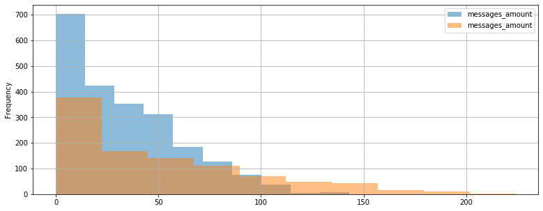

```python
# для смс в обоих тарифах
smart_users['messages_amount'].plot(kind='hist',alpha=0.5,figsize=(13,5),grid=True,legend='smart')
ultra_users['messages_amount'].plot(kind='hist',alpha=0.5,figsize=(13,5),grid=True,legend='ultra');
```

```python
# посчитаем дисперсию и стандартное отклонение для smart
smart_msg_variance = np.var(smart_users['messages_amount'])
smart_msg_std = np.std(smart_users['messages_amount'])
smart_msg_mean = np.mean(smart_users['messages_amount'])
print(f'Дисперсия smart: {smart_msg_variance}\nСтандартное отклонение smart: {smart_msg_std}\nСреднее значение: {smart_msg_mean}')
```

```
Дисперсия smart: 796.455482917076
Стандартное отклонение smart: 28.221542886898938
Среднее значение: 33.384028712427096
```

```python
# посчитаем дисперсию и стандартное отклонение для ultra
ultra_msg_variance = np.var(ultra_users['messages_amount'])
ultra_msg_std = np.std(ultra_users['messages_amount'])
ultra_msg_mean = np.mean(ultra_users['messages_amount'])
print(f'Дисперсия ultra: {ultra_msg_variance}\nСтандартное отклонение ultra: {ultra_msg_std}\nСреднее значение: {ultra_msg_mean}')
```

```
Дисперсия ultra: 2282.9460753948824
Стандартное отклонение ultra: 47.78018496610161
Среднее значение: 49.36345177664975
```

#### Звонки

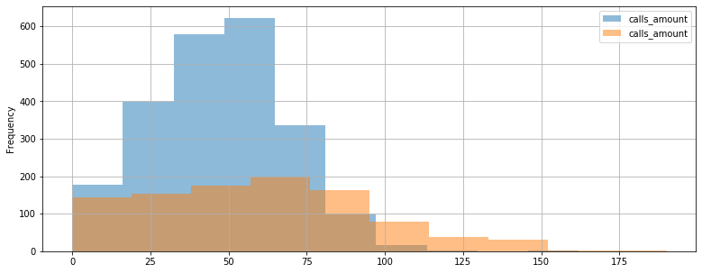

```python
#для звонков в обоих тарифах
smart_users['calls_amount'].plot(kind='hist',alpha=0.5,figsize=(13,5),grid=True,legend='smart')
ultra_users['calls_amount'].plot(kind='hist',alpha=0.5,figsize=(13,5),grid=True,legend='ultra');
```

```python
# посчитаем дисперсию и стандартное отклонение для smart
smart_calls_variance = np.var(smart_users['calls_amount'])
smart_calls_std = np.std(smart_users['calls_amount'])
smart_calls_mean = np.mean(smart_users['calls_amount'])
print(f'Дисперсия smart: {smart_calls_variance}\nСтандартное отклонение smart: {smart_calls_std}\nСреднее значение: {smart_calls_mean}')
```

```
Дисперсия smart: 442.44811964155355
Стандартное отклонение smart: 21.034450780601656
Среднее значение: 46.94751009421265
```

```python
# посчитаем дисперсию и стандартное отклонение для ultra
ultra_calls_variance = np.var(ultra_users['calls_amount'])
ultra_calls_std = np.std(ultra_users['calls_amount'])
ultra_calls_mean = np.mean(ultra_users['calls_amount'])
print(f'Дисперсия ultra: {ultra_calls_variance}\nСтандартное отклонение ultra: {ultra_calls_std} \nСреднее значение: {ultra_calls_mean}')
```

```
Дисперсия ultra: 1263.4232327552888
Стандартное отклонение ultra: 35.54466532062567
Среднее значение: 59.236548223350255
```

#### Интернет

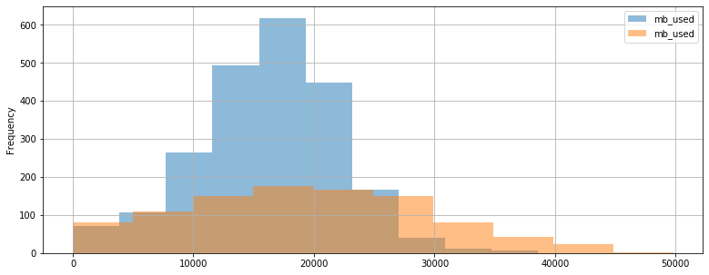

```python
#для звонков в обоих тарифах
smart_users['mb_used'].plot(kind='hist',alpha=0.5,figsize=(13,5),grid=True,legend='smart')
ultra_users['mb_used'].plot(kind='hist',alpha=0.5,figsize=(13,5),grid=True,legend='ultra');
```

```python
# посчитаем дисперсию и стандартное отклонение для smart
smart_internet_variance = np.var(smart_users['mb_used'])
smart_internet_std = np.std(smart_users['mb_used'])
smart_internet_mean = np.mean(smart_users['mb_used'])
print(f'Дисперсия smart: {smart_internet_variance}\nСтандартное отклонение smart: {smart_internet_std}\nСреднее значение: {smart_internet_mean}')
```

```
Дисперсия smart: 34530412.73703965
Стандартное отклонение smart: 5876.25839604077
Среднее значение: 16229.188425302826
```

```python
# посчитаем дисперсию и стандартное отклонение для ultra
ultra_internet_variance = np.var(ultra_users['mb_used'])
ultra_internet_std = np.std(ultra_users['mb_used'])
ultra_internet_mean = np.mean(ultra_users['mb_used'])
print(f'Дисперсия ultra: {ultra_internet_variance}\nСтандартное отклонение ultra: {ultra_internet_std} \nСреднее значение: {ultra_internet_mean}')
```

```
Дисперсия ultra: 101832133.10806875
Стандартное отклонение ultra: 10091.190866695008
Среднее значение: 19486.90152284264
```

#### Вывод

На основе этих результатов,можно предположить,что людям,использующим тариф *ultra* необходимо больше минут,sms и гигабайт,чем людям,использующим тариф *smart*

Что касается распределений,все распределения стремятся к нормальным,кроме распределения сообщений,потому что там значения NaN мы заменили нулевыми значениями,потому что предположили,что если сообщений за пользователем нет - значит он отправил 0 сообщений.

## Шаг 4. Проверка гипотез

#### Гипотеза 1

Выдвинем нулевую гипотезу о том,что средняя выручка пользователей тарифов «Ультра» и «Смарт» одинаковая. Тогда альтернативная гипотеза будет заключаться в том,что средняя выручка с двух тарифов различается.

Для проверки данной гипотезы воспользуемся методом гипотезы о равенстве средних двух генеральных совокупностей.

```python
# зададим пороговое значение alpha = 5%
alpha = .05
```

```python
#получим выручку по тарифу смарт
smart_income = smart_users['income']
smart_income.head()
```

```
user_id  month
1001     11       1350.0
         12        550.0
1002     6         550.0
         7        1150.0
         8        1550.0
Name: income, dtype: float64
```

```python
# получим выручку по тарифу ультра
ultra_income = ultra_users['income']
ultra_income.head()
```

```
user_id  month
1000     5        1950.0
         6        1950.0
         7        1950.0
         8        1950.0
         9        1950.0
Name: income, dtype: float64
```

```python
# проведем проверку дисперсий выборок вручную
[np.var(series, ddof=1) for series in [ultra_income,smart_income]]
```

```
[143491.24055961374, 673931.3213632443]
```

Делаем вывод о том,что параметр `equal_var` нужно установить в значение `False`,так как разница в дисперсиях очень велика.

```python
#проверим нашу нулевую гипотезу
result1 = st.ttest_ind(ultra_income,smart_income,equal_var=False)

print('p-значение: ', result1.pvalue)
```

```
p-значение:  2.7240946993530856e-246
```

```python
if result1.pvalue < alpha:
    print('Отвергаем нулевую гипотезу')
else:
    print("Не получилось отвергнуть нулевую гипотезу")
```

```
Отвергаем нулевую гипотезу
```

#### Вывод

Делаем вывод о том,что наша нулевая гипотеза неверна,поэтому ее мы рассматривать не будем.

#### Гипотеза 2

Выдвинем нулевую гипотезу о том,что средняя выручка пользователей из Москвы не различается от выручки пользователей из других регионов.Тогда альтернативная гипотеза заключается в том,что выручка пользователей из Москвы различается от выручки пользователей других регионов.

Возспользуемся тем же методом проверки 2 средних,и разделим нашу генеральную совокупность на 2 выборкит - те,кто живут в Мосвке и те,кто живут в других регионах.

```python
#разделим нашу совокупность на 2 выборки
moscow_users_income = used_data.query('city == "москва"')['income']
moscow_users_income.head()
```

```
user_id  month
1001     11       1350.0
         12        550.0
1003     8        1950.0
         9        1950.0
         10       1950.0
Name: income, dtype: float64
```

```python
other_users_income = used_data.query('city != "москва"')['income']
other_users_income.head()
```

```
user_id  month
1000     5        1950.0
         6        1950.0
         7        1950.0
         8        1950.0
         9        1950.0
Name: income, dtype: float64
```

```python
# проведем проверку дисперсий вручную
[np.var(series, ddof=1) for series in [moscow_users_income,other_users_income]]
```

```
[566183.0292184273, 656766.5955122438]
```

Делаем вывод о том,что параметр `equal_var` можно оставить в значении `True`,так как разница в дисперсиях не такая уж и большая.

```python
# проверим гипотезу о равенстве
result2 = st.ttest_ind(moscow_users_income,other_users_income)

print('p-значение: ', result2.pvalue)
```

```
p-значение:  0.531666503831252
```

```python
if result2.pvalue < alpha:
    print('Отвергаем нулевую гипотезу')
else:
    print("Не получилось отвергнуть нулевую гипотезу")
```

```
Не получилось отвергнуть нулевую гипотезу
```

#### Вывод

Мы делаем вывод о том,что не надо отвергать нулевую гипотезу и ее стоит рассмотреть и принять во внимание.

## Рекомендации

На данный момент есть 2 пути развития компании:

1. Так как пользователей тарифа смарт больше,то он приносит больше денег компании,значит можно развивать его дальше.
2. Или же, можно направить все силы на то,чтобы привлечь как можно больше клиентов в тариф `ultra` => выручка будет расти